# Tracking COVID-19 in the United States

## Overview

### Total Cases and Total Deaths

These show the cumulative total of cases and deaths by day. I have also denoted the current cumulative totals. These total values are important; however they are not helpful for figuring out whether the pandemic is slowing down or growing as it is difficult to see trends in cumulative curves like these.

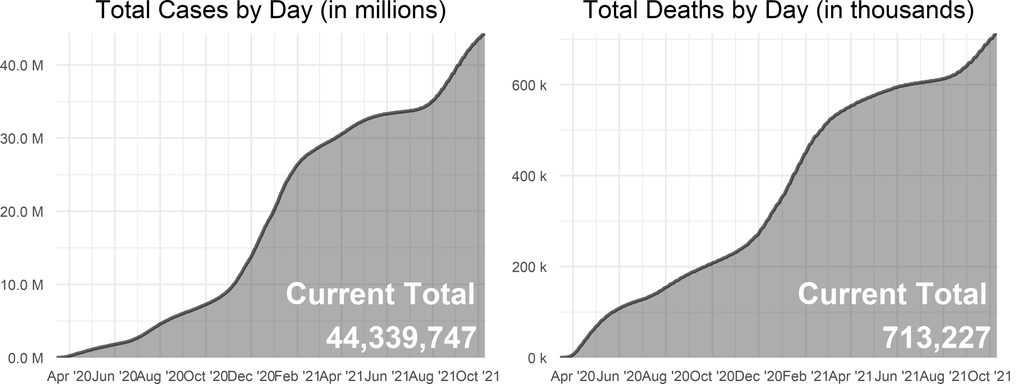

### New Cases

Looking at new cases each day can help us see if the pandemic is slowing. A decreasing number of new cases per day is evidence that the pandemic is slowing down.

There can be a lot of variability in the daily case totals due to a variety of variables. One example is the availability of tests; cases will go down if there is a scarcity of tests and rise dramatically when more tests become available. There is also a cyclical nature to the daily new cases with counts often being lower on weekends and higher on weekdays. One way to help get a better sense of the overall trend is by smoothing the data using a moving average.

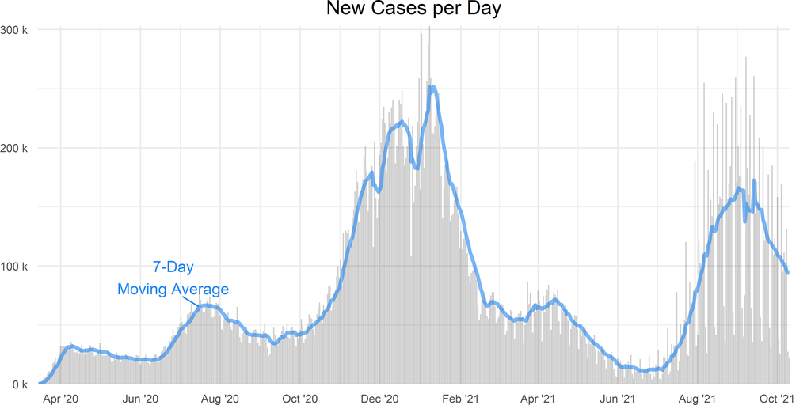

### New Deaths and Case Fatality

COVID-19 is much deadlier than the common flu. One way to measure the impact is to look at the case fatality percentage, which is the total number of deaths divided by the total number of cases.

Similar to new cases there is a cyclical nature to daily deaths. This may be due to reporting times where counts on weekdays are often higher than those on weekends. Other variability in the data can also occurs when states change how they are assigning COVID-19 deaths, such as counting nursing home deaths and/or pneumonia deaths as COVID-19 deaths.

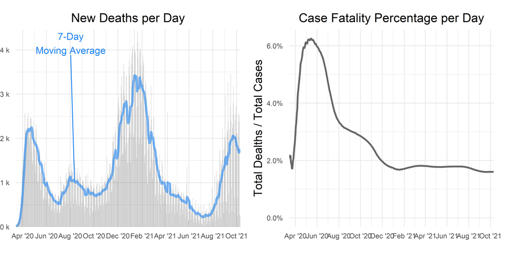

### Values for Past 14 Days

The actual values for the previous 14 days are detailed in the table below.

| Date | Total Cases | Total Deaths | New Cases | New Cases 7-MA | New Deaths | New Deaths 7-MA | Death Percentage |
| --- | --- | --- | --- | --- | --- | --- | --- |
| Sun, Oct 10, 2021 | 44,339,747 | 713,227 | 22,194 | 93,814 | 255 | 1,691 | 1.609% |
| Sat, Oct 09, 2021 | 44,317,553 | 712,972 | 27,501 | 94,245 | 279 | 1,689 | 1.609% |
| Fri, Oct 08, 2021 | 44,290,052 | 712,693 | 131,142 | 95,917 | 2,520 | 1,741 | 1.609% |
| Thu, Oct 07, 2021 | 44,158,910 | 710,173 | 100,083 | 99,795 | 2,392 | 1,682 | 1.608% |
| Wed, Oct 06, 2021 | 44,058,827 | 707,781 | 111,338 | 101,296 | 2,556 | 1,730 | 1.606% |
| Tue, Oct 05, 2021 | 43,947,489 | 705,225 | 95,234 | 103,001 | 1,730 | 1,728 | 1.605% |
| Mon, Oct 04, 2021 | 43,852,255 | 703,495 | 169,207 | 105,054 | 2,109 | 1,774 | 1.604% |
| Sun, Oct 03, 2021 | 43,683,048 | 701,386 | 25,215 | 107,312 | 237 | 1,817 | 1.606% |
| Sat, Oct 02, 2021 | 43,657,833 | 701,149 | 39,206 | 108,132 | 648 | 1,827 | 1.606% |
| Fri, Oct 01, 2021 | 43,618,627 | 700,501 | 158,284 | 109,322 | 2,106 | 1,832 | 1.606% |
| Thu, Sep 30, 2021 | 43,460,343 | 698,395 | 110,594 | 112,060 | 2,729 | 1,893 | 1.607% |
| Wed, Sep 29, 2021 | 43,349,749 | 695,666 | 123,267 | 114,238 | 2,540 | 1,958 | 1.605% |
| Tue, Sep 28, 2021 | 43,226,482 | 693,126 | 109,605 | 115,545 | 2,049 | 1,995 | 1.603% |
| Mon, Sep 27, 2021 | 43,116,877 | 691,077 | 185,016 | 117,207 | 2,410 | 2,022 | 1.603% |

JH data as of October, 10 2021  
[Code](https://github.com/MarEichler/covid19) last updated October, 11 2021 10:02 PDT

## Growth Factor

### Is the pandemic slowing?

One important calculation is the growth factor, as outlined in [3Blue1Brown’s youtube video on exponential growth](https://www.youtube.com/watch?v=Kas0tIxDvrg) . The growth factor is calculated as follows:

$$\text{Growth Factor} = \frac{ \text{New-Cases}_N}{\text{New-Cases}_{N-1}}$$
where $N$ is a given day. Essentialy this is taking the amount of new cases today and dividing them by the amount of new cases yesterday.

The growth factor can be very helpful in determining if the pandemic is slowing. If the growth factor is less than 1, this means that the amount of new cases today is less than yesterday. Once there are multiple days with a growth factor less than 1 it is a strong sign that the pandemic is slowing down.

#### Adjustment to Growth Factor

What if there were 0 cases yesterday? This would make the growth factor undefined (or $\infty$ according to R). This makes it difficult to look at trends. I have adjusted the growth factor so that if the previous day had 0 cases, the current day’s growth factor is equal to the number of new cases:

$$\text{Growth Factor} = \begin{cases}
\frac{ \text{New-Cases}_N}{\text{New-Cases}_{N-1}} & \text{if } \text{New-Cases}_{N-1} \neq 0
\\[1ex]
\text{New-Cases}_N & \text{if } \text{New-Cases}_{N-1} = 0
\end{cases}$$
I made this adjustment for the early or late stages of the pandemic when the number of cases per day are 0, 1, or 2. However, given the test scarcity and reporting times there are situations in counties or states where there are 0 cases one day and then hundreds or thousands the next day. This large variability causes spikes in the growth factor in some plots.

### Growth Factor Plot

Similar to the new cases per day, there can be a lot of variability in growth factors In order to get a better sense of the trend I am showing a 7-day moving average of the growth factor.

Between mid-April and mid-June the growth factor hovered around 1, showing that although cases were decreasing there was not substantial decrease in growth. After states began to re-open there was a dramatic increase in new-cases starting in mid-June. Between mid-June and mid-July cases started increasing dramatically which lead lead to the 7-day moving average growth factor to be above 1 for a month. From mid-July to October the 7-day moving average growth factor has oscillating around 1. Starting in the Fall with the dramatic increase of new cases, the 7-day moving average growth factor has been consistently above 1.

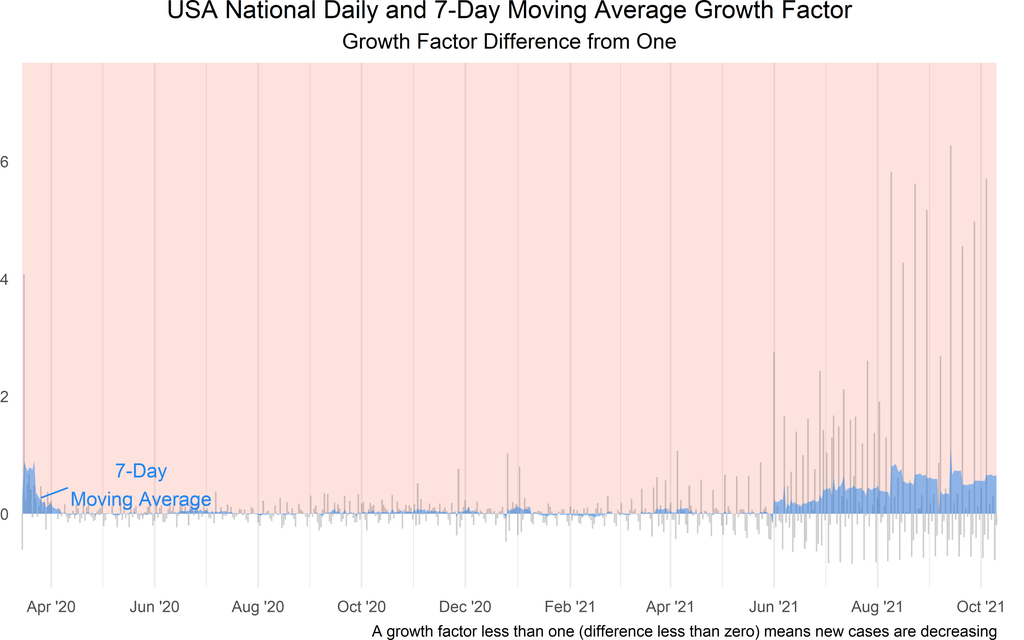

### Last Two Weeks

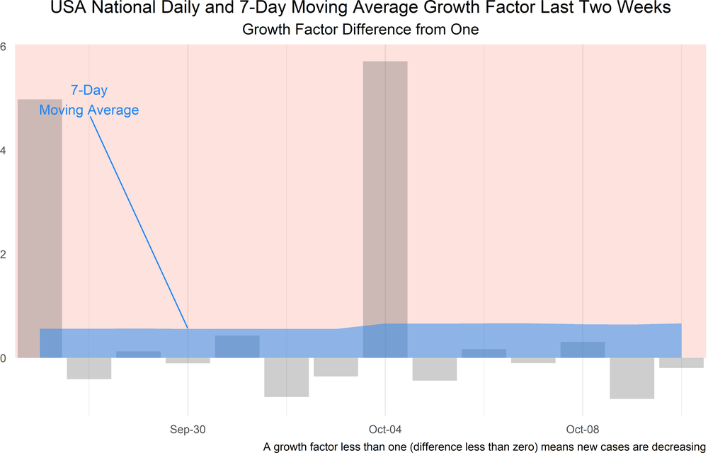

### Recent Values by Day for US

The actual values for the previous 14 days are detailed in the table below.

| Date | Total Cases | New Cases | New Cases 7-Day MA | Growth Factor | Growth Factor 7-day MA |
| --- | --- | --- | --- | --- | --- |
| Sun, Oct 10, 2021 | 44,339,747 | 22,194 | 93,814 | 0.81 | 1.67 |
| Sat, Oct 09, 2021 | 44,317,553 | 27,501 | 94,245 | 0.21 | 1.64 |
| Fri, Oct 08, 2021 | 44,290,052 | 131,142 | 95,917 | 1.31 | 1.65 |
| Thu, Oct 07, 2021 | 44,158,910 | 100,083 | 99,795 | 0.9 | 1.67 |
| Wed, Oct 06, 2021 | 44,058,827 | 111,338 | 101,296 | 1.17 | 1.67 |
| Tue, Oct 05, 2021 | 43,947,489 | 95,234 | 103,001 | 0.56 | 1.66 |
| Mon, Oct 04, 2021 | 43,852,255 | 169,207 | 105,054 | 6.71 | 1.66 |
| Sun, Oct 03, 2021 | 43,683,048 | 25,215 | 107,312 | 0.64 | 1.56 |
| Sat, Oct 02, 2021 | 43,657,833 | 39,206 | 108,132 | 0.25 | 1.56 |
| Fri, Oct 01, 2021 | 43,618,627 | 158,284 | 109,322 | 1.43 | 1.56 |
| Thu, Sep 30, 2021 | 43,460,343 | 110,594 | 112,060 | 0.9 | 1.56 |
| Wed, Sep 29, 2021 | 43,349,749 | 123,267 | 114,238 | 1.12 | 1.57 |
| Tue, Sep 28, 2021 | 43,226,482 | 109,605 | 115,545 | 0.59 | 1.56 |
| Mon, Sep 27, 2021 | 43,116,877 | 185,016 | 117,207 | 5.98 | 1.56 |

JH data as of October, 10 2021  
[Code](https://github.com/MarEichler/covid19) last updated October, 11 2021 10:02 PDT

## State Trends

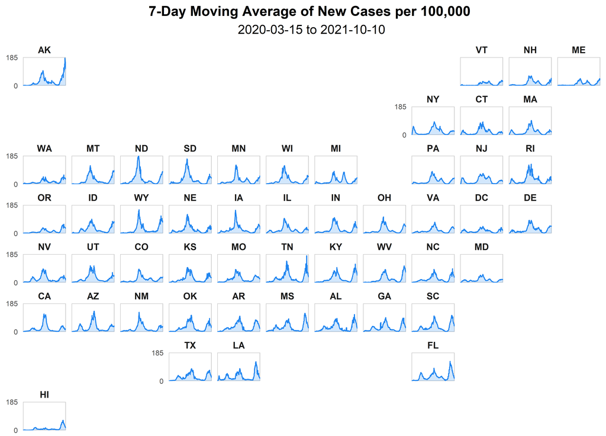

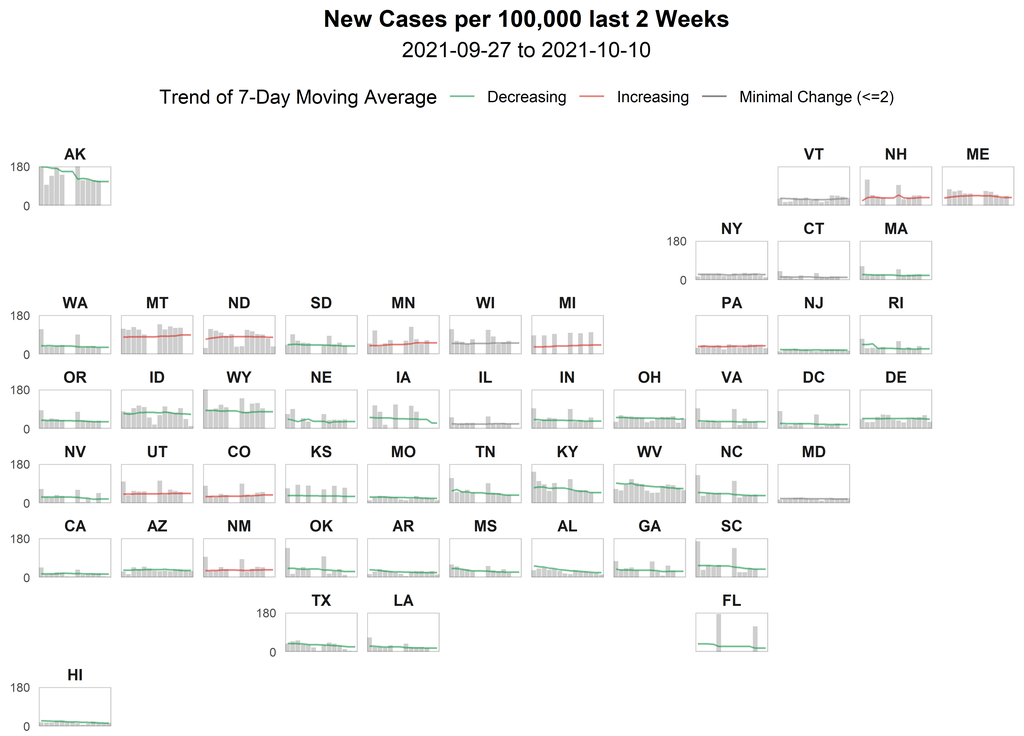

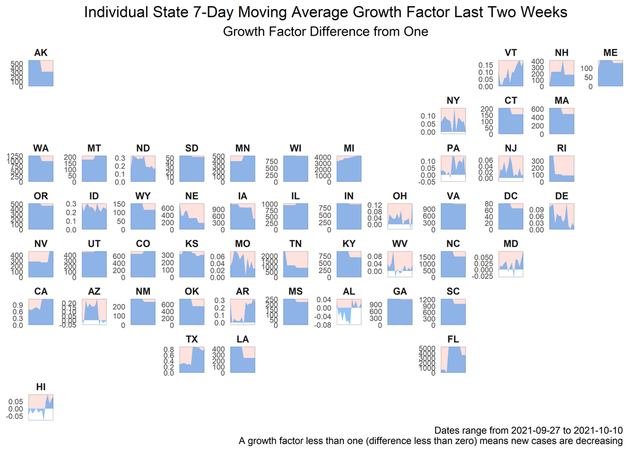

Note 2021-02-19: IA had a huge increase in cases on 2/19/21, likely related to a change in report. This date has been removed from plots and moving average calculations

JH data as of October, 10 2021  
[Code](https://github.com/MarEichler/covid19) last updated October, 11 2021 10:02 PDT

## Current New Cases

[figure not shown]

JH data as of October, 10 2021  
[Code](https://github.com/MarEichler/covid19) last updated October, 11 2021 10:02 PDT

## Total Cases

[figure not shown]

JH data as of October, 10 2021  
[Code](https://github.com/MarEichler/covid19) last updated October, 11 2021 10:02 PDT

## Data

COVID-19 cases at the county level are taken from [Johns Hopkins](https://github.com/CSSEGISandData/COVID-19/tree/master/csse_covid_19_data/csse_covid_19_time_series).

Population numbers are taken from the [US Census State Population Totals](https://www.census.gov/data/datasets/time-series/demo/popest/2010s-state-total.html#par_textimage_1873399417) and the [US Census County Population Totals](https://www.census.gov/data/datasets/time-series/demo/popest/2010s-counties-total.html). The projected population for 2019 values were used to calculate the per capita measures.

### Plot Dates

Many of the plots have been restricted to show data on March 15, 2020 and after. This is when case numbers started to rise and preventative measures started to increase dramatically.

### Data Limitations

A large limitation for this data is that reported new cases (and thus the growth factor) may not consistently and accurately represent the true number of new cases each day. As mentioned before, this could be due to test availability, reporting protocols, and a number of other variables. It is important to note that this information is a helpful tool in trying to understand the pandemic, but it may not reflect the entire story.

JH data as of October, 10 2021  
[Code](https://github.com/MarEichler/covid19) last updated October, 11 2021 10:02 PDT